# Factors in R

Author

Andrew Gard

```r
library(tidyverse)
theme_set(theme_minimal())

library(readxl)
scooby <- read_excel("scooby.xlsx")

scooby_sm <- scooby |>
  filter(format == "TV Series") |>
  select(title,
         date_aired,
         imdb,
         motive)
```

Categorical variables (or *factors* as they are referred to when working in R) are variables that assign observations to specific groups. The possible values of a factor variable are called *levels*.

## Factors, characters, and other types

As a general rule, `tidyverse` functions treat character vectors as factors.

```r
glimpse(scooby_sm)
```

```
Rows: 374
Columns: 4
$ title      <chr> "What a Night for a Knight", "A Clue for Scooby Doo", "Hass…
$ date_aired <dttm> 1969-09-13, 1969-09-20, 1969-09-27, 1969-10-04, 1969-10-11…
$ imdb       <dbl> 8.1, 8.1, 8.0, 7.8, 7.5, 8.4, 7.6, 8.2, 8.1, 8.0, 8.5, 8.2,…
$ motive     <chr> "Theft", "Theft", "Treasure", "Natural Resource", "Competit…
```

```r
scooby_sm |>
  count(motive)
```

```
# A tibble: 17 × 2
   motive               n
   <chr>            <int>
 1 Abduction            3
 2 Assistance           2
 3 Competition        130
 4 Conquer             33
 5 Counterfeit          6
 6 Entertainment        3
 7 Extortion            3
 8 Imagination          1
 9 Inheritance          6
10 Natural Resource    19
11 Preservation        10
12 Safety               2
13 Simulation           2
14 Smuggling           19
15 Theft               93
16 Treasure            40
17 <NA>                 2
```

Use `as.factor()` to explicitly coerce variables to factors. This is particularly useful when category levels are numeric.

```r
glimpse(mtcars)
```

```
Rows: 32
Columns: 11
$ mpg  <dbl> 21.0, 21.0, 22.8, 21.4, 18.7, 18.1, 14.3, 24.4, 22.8, 19.2, 17.8,…
$ cyl  <dbl> 6, 6, 4, 6, 8, 6, 8, 4, 4, 6, 6, 8, 8, 8, 8, 8, 8, 4, 4, 4, 4, 8,…
$ disp <dbl> 160.0, 160.0, 108.0, 258.0, 360.0, 225.0, 360.0, 146.7, 140.8, 16…
$ hp   <dbl> 110, 110, 93, 110, 175, 105, 245, 62, 95, 123, 123, 180, 180, 180…
$ drat <dbl> 3.90, 3.90, 3.85, 3.08, 3.15, 2.76, 3.21, 3.69, 3.92, 3.92, 3.92,…
$ wt   <dbl> 2.620, 2.875, 2.320, 3.215, 3.440, 3.460, 3.570, 3.190, 3.150, 3.…
$ qsec <dbl> 16.46, 17.02, 18.61, 19.44, 17.02, 20.22, 15.84, 20.00, 22.90, 18…
$ vs   <dbl> 0, 0, 1, 1, 0, 1, 0, 1, 1, 1, 1, 0, 0, 0, 0, 0, 0, 1, 1, 1, 1, 0,…
$ am   <dbl> 1, 1, 1, 0, 0, 0, 0, 0, 0, 0, 0, 0, 0, 0, 0, 0, 0, 1, 1, 1, 0, 0,…
$ gear <dbl> 4, 4, 4, 3, 3, 3, 3, 4, 4, 4, 4, 3, 3, 3, 3, 3, 3, 4, 4, 4, 3, 3,…
$ carb <dbl> 4, 4, 1, 1, 2, 1, 4, 2, 2, 4, 4, 3, 3, 3, 4, 4, 4, 1, 2, 1, 1, 2,…
```

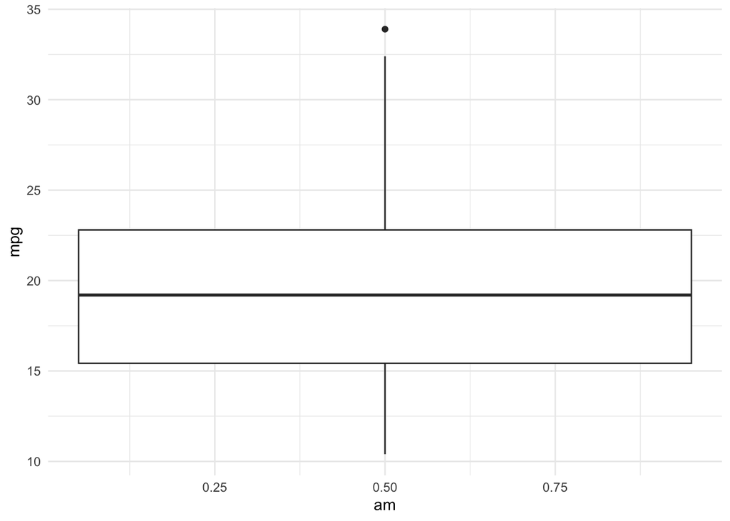

```r
ggplot(mtcars, aes(x = am,
                   y = mpg)) +
  geom_boxplot() # not what we want
```

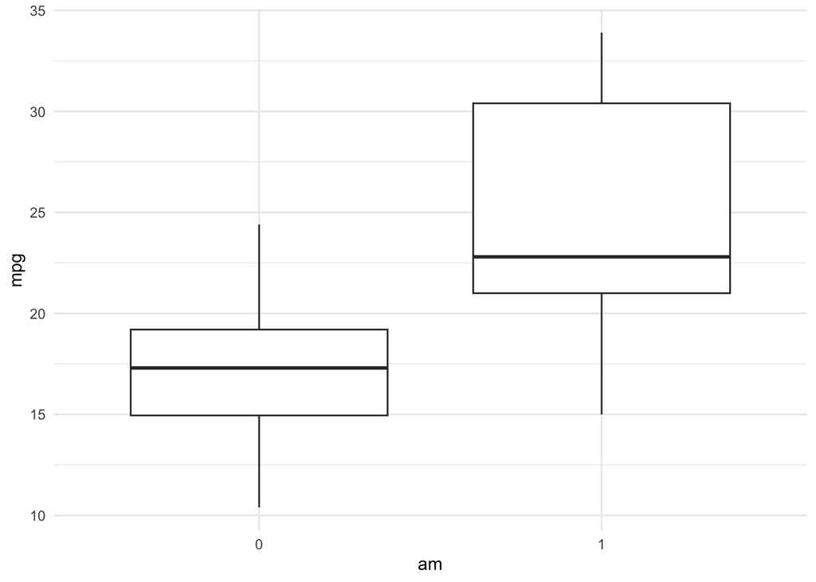

```r
mtcars2 <- mtcars |>
  mutate(am = as.factor(am))

ggplot(mtcars2, aes(x = am,
                    y = mpg)) +
  geom_boxplot()
```

## Relabeling factors

There are many options for changing the text used to label factor levels, but `fct_recode()` is a solid choice.

```r
mtcars2 <- mtcars2 |>
  mutate(am = fct_recode(am,
                         "automatic" = "0",
                         "manual" = "1"))
mtcars2 |>
  count(am)
```

```
         am  n
1 automatic 19
2    manual 13
```

Notice the syntax, “new_name” = “old_name”, which is common in `tidyverse` R.

When you have a large number of different factor levels, it may be helpful to lump the less common ones into an “other” category. For instance, the next chunk combines all categories with fewer than 20 occurrences.

```r
scooby_sm2 <- scooby_sm |>
  mutate(motive = fct_lump_min(motive,
                               min = 20))
scooby_sm2 |>
  count(motive) |>
  arrange(-n)
```

```
# A tibble: 6 × 2
  motive          n
  <fct>       <int>
1 Competition   130
2 Theft          93
3 Other          76
4 Treasure       40
5 Conquer        33
6 <NA>            2
```

Also check out `fct_lump_n()` to specify the number of levels retained, `fct_lump_prop()` to lump low-percentage levels, and `fct_lump_lowfreq()` to try to force the new “Other” level to have lowest frequency.

## Rearranging levels

Sometimes the order of factor levels matters. Use `fct_relevel()` to shift levels to the front.

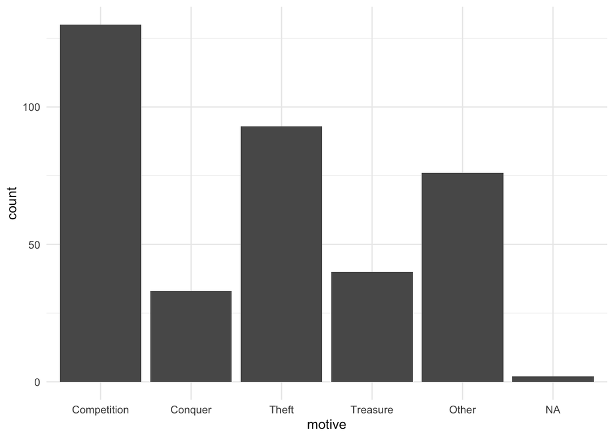

```r
ggplot(scooby_sm2,
       aes(x = motive)) +
  geom_bar()
```

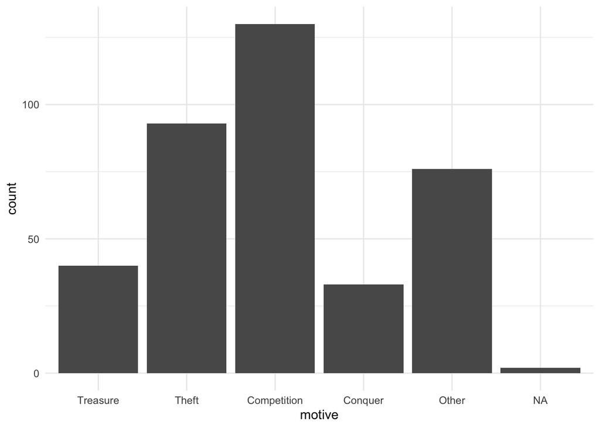

```r
scooby_sm3 <- scooby_sm2 |>
  mutate(motive = fct_relevel(motive,
                              "Treasure",
                              "Theft"))

ggplot(scooby_sm3,
       aes(x = motive)) +
  geom_bar()
```

Often, you just want to put the most common factor levels first. Use `fct_infreq()` to accomplish this.

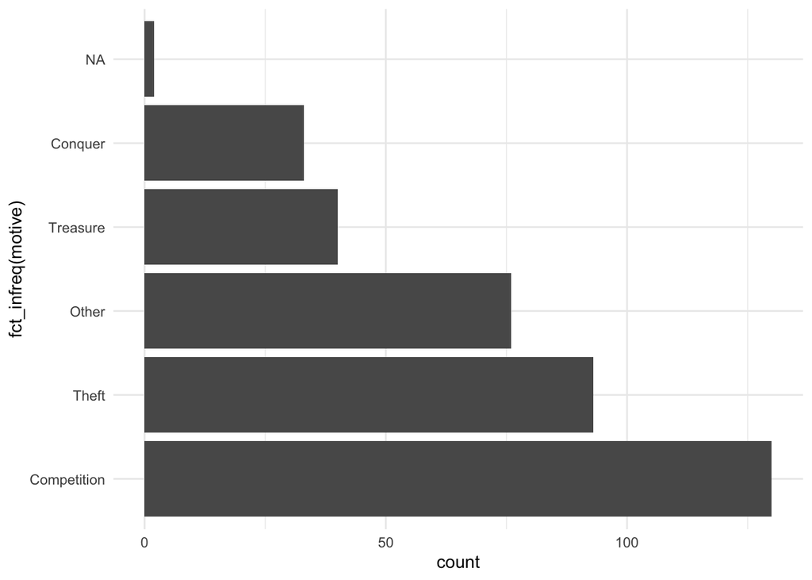

```r
ggplot(scooby_sm2, aes(y = fct_infreq(motive))) +
  geom_bar()
```

You can also reverse the order of the factor levels with `fct_rev`.

## Reordering levels using a second variable

For some plots, it can be natural to order a categorical variable using a numeric one. For instance, in the next plot it would be preferable to show the various motives in increasing order of imdb ratings.

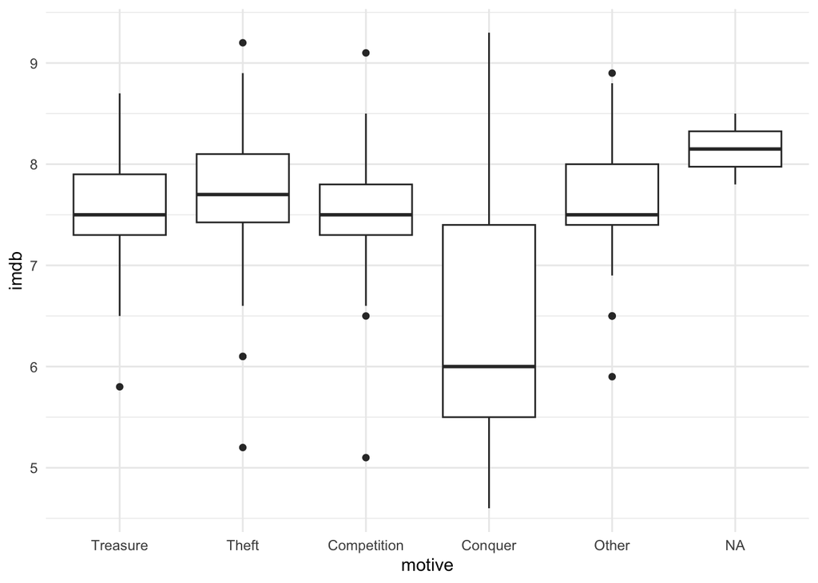

```r
ggplot(scooby_sm3, aes(x = motive,
                       y = imdb)) +
  geom_boxplot()
```

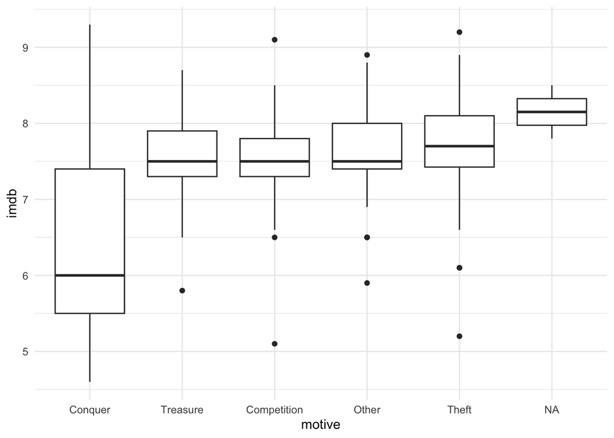

```r
scooby_sm4 <- scooby_sm3 |>
  mutate(motive = fct_reorder(motive,
                              imdb))

ggplot(scooby_sm4, aes(x = motive,
                       y = imdb)) +
  geom_boxplot()
```

By default, `fct_reorder` sorts using the median. You can specify a different function (like mean) by adding a `.fun` argument.

## Ordered factors

Occasionally you may encounter ordered factors, ones of class `ord`. For the most part, you can treat these like regular factors.

```r
glimpse(diamonds)
```

```
Rows: 53,940
Columns: 10
$ carat   <dbl> 0.23, 0.21, 0.23, 0.29, 0.31, 0.24, 0.24, 0.26, 0.22, 0.23, 0.…
$ cut     <ord> Ideal, Premium, Good, Premium, Good, Very Good, Very Good, Ver…
$ color   <ord> E, E, E, I, J, J, I, H, E, H, J, J, F, J, E, E, I, J, J, J, I,…
$ clarity <ord> SI2, SI1, VS1, VS2, SI2, VVS2, VVS1, SI1, VS2, VS1, SI1, VS1, …
$ depth   <dbl> 61.5, 59.8, 56.9, 62.4, 63.3, 62.8, 62.3, 61.9, 65.1, 59.4, 64…
$ table   <dbl> 55, 61, 65, 58, 58, 57, 57, 55, 61, 61, 55, 56, 61, 54, 62, 58…
$ price   <int> 326, 326, 327, 334, 335, 336, 336, 337, 337, 338, 339, 340, 34…
$ x       <dbl> 3.95, 3.89, 4.05, 4.20, 4.34, 3.94, 3.95, 4.07, 3.87, 4.00, 4.…
$ y       <dbl> 3.98, 3.84, 4.07, 4.23, 4.35, 3.96, 3.98, 4.11, 3.78, 4.05, 4.…
$ z       <dbl> 2.43, 2.31, 2.31, 2.63, 2.75, 2.48, 2.47, 2.53, 2.49, 2.39, 2.…
```

```r
diamonds |>
  count(cut)
```

```
# A tibble: 5 × 2
  cut           n
  <ord>     <int>
1 Fair       1610
2 Good       4906
3 Very Good 12082
4 Premium   13791
5 Ideal     21551
```

Specifying that a factor is ordered can occasionally matter in modeling applications and certain forms of statistical inference. Other than that, the most visible difference with ordered factors in R is how they’re displayed by `ggplot`.

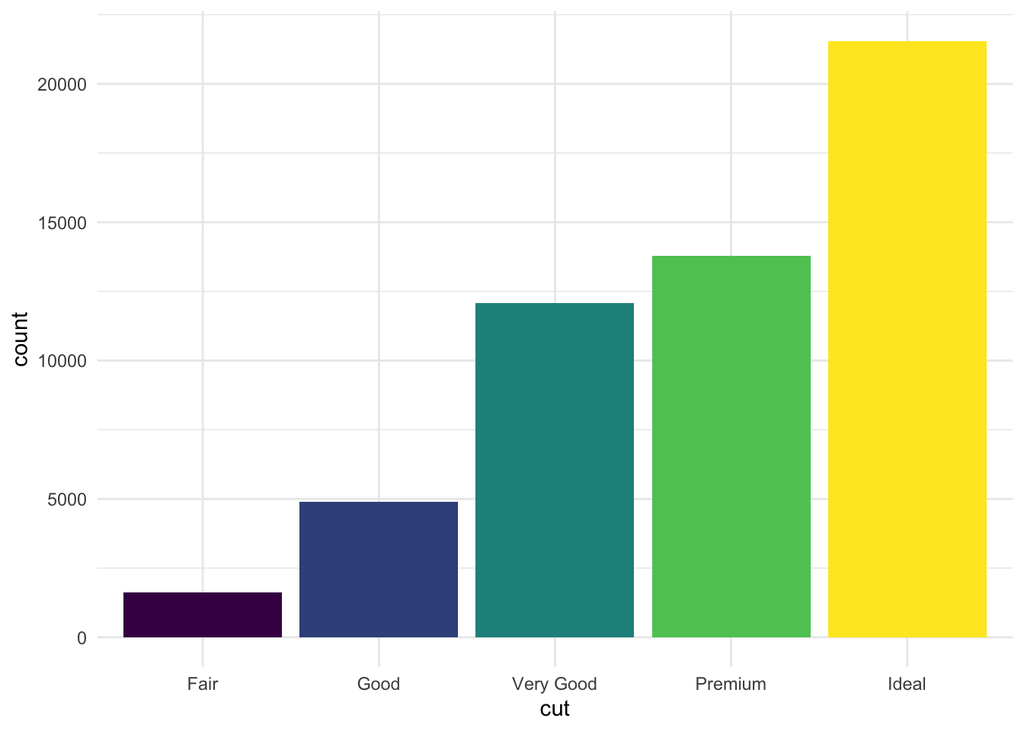

```r
ggplot(diamonds, aes(x = cut,
                     fill = cut)) +
  geom_bar(show.legend = FALSE)
```

By default, ordered factors are colored using the `viridis` palette, which is has a distinct order to it.